# Software Faultiness Analysis - Marco Gatto

# Project Purpose

The purpose of the project is to carry out a complete data analysis based on a dataset. In particular, the dataset Lucene provides Java-based indexing and search technology, as well as spellchecking, hit highlighting and advanced analysis/tokenization capabilities.

# Import of the dataset

In order to import the dataset, it is used the build-in function ‘read.csv’. It is also shown a preview of the first rows of the dataset.

```r
lucene <- read.csv(
  file='lucene-2.4.csv',
  head=TRUE,
  sep=',')

head(lucene)
```

|  | name | version | name.1 | wmc | dit | noc | cbo | rfc | lcom | ca | ce | npm | lcom3 | loc | dam | moa | mfa | cam | ic | cbm | amc | max_cc | avg_cc | bug |
| --- | --- | --- | --- | --- | --- | --- | --- | --- | --- | --- | --- | --- | --- | --- | --- | --- | --- | --- | --- | --- | --- | --- | --- | --- |
| 1 | lucene | 2.4 | org.apache.lucene.index.DocInverterPerThread | 5 | 2 | 0 | 19 | 18 | 0 | 8 | 15 | 4 | 0.7857143 | 84 | 0.0000000 | 7 | 0.5000000 | 0.4000000 | 0 | 0 | 14.40 | 3 | 1.20 | 1 |
| 2 | lucene | 2.4 | org.apache.lucene.search.FuzzyQuery | 10 | 3 | 0 | 13 | 41 | 7 | 1 | 12 | 9 | 0.6388889 | 286 | 0.5000000 | 0 | 0.7200000 | 0.2857143 | 2 | 6 | 27.20 | 6 | 1.40 | 3 |
| 3 | lucene | 2.4 | org.apache.lucene.search.QueryTermVector | 10 | 1 | 0 | 4 | 38 | 0 | 0 | 4 | 9 | 0.3888889 | 287 | 1.0000000 | 0 | 0.0000000 | 0.3400000 | 0 | 0 | 27.50 | 5 | 1.60 | 0 |
| 4 | lucene | 2.4 | org.apache.lucene.index.ReadOnlySegmentReader | 4 | 4 | 0 | 3 | 7 | 6 | 2 | 2 | 1 | 2.0000000 | 26 | 0.0000000 | 0 | 0.9812500 | 0.5000000 | 2 | 3 | 5.50 | 3 | 1.25 | 0 |
| 5 | lucene | 2.4 | org.apache.lucene.index.DirectoryIndexReader | 25 | 2 | 2 | 20 | 82 | 160 | 5 | 18 | 8 | 0.8819444 | 596 | 0.8333333 | 5 | 0.7684211 | 0.1979167 | 2 | 8 | 22.36 | 3 | 1.08 | 10 |
| 6 | lucene | 2.4 | org.apache.lucene.index.DocFieldConsumerPerThread | 5 | 1 | 3 | 13 | 6 | 10 | 10 | 3 | 0 | 2.0000000 | 8 | 0.0000000 | 0 | 0.0000000 | 0.6000000 | 0 | 0 | 0.60 | 1 | 0.80 | 0 |

The dataset is composed by 340 rows and 24 columns.

```r
cat("Number of columns:", length(lucene))
```

```
## Number of columns: 24
```

```r
cat("Number of rows:", length(lucene[[1]]))
```

```
## Number of rows: 340
```

The names of the columns are shown below.

```r
colnames(lucene)
```

```
##  [1] "name"    "version" "name.1"  "wmc"     "dit"     "noc"     "cbo"
##  [8] "rfc"     "lcom"    "ca"      "ce"      "npm"     "lcom3"   "loc"
## [15] "dam"     "moa"     "mfa"     "cam"     "ic"      "cbm"     "amc"
## [22] "max_cc"  "avg_cc"  "bug"
```

# Selection and visualization of the dependent variable

The dependent variable must be related to the software faultiness. Looking at the available columns in the dataset, the ‘bug’ column is the only one that meets this requirement. In particular, it represents the number of defects reported in the analyzed artifacts.

```r
sw_fault <- lucene$bug

head(sw_fault)
```

```
## [1]  1  3  0  0 10  0
```

Instead of looking at the single values of the variable, it is possible to show the histogram representing the their frequencies. In this way, it is possible to see whether the data are mostly focused around some values.

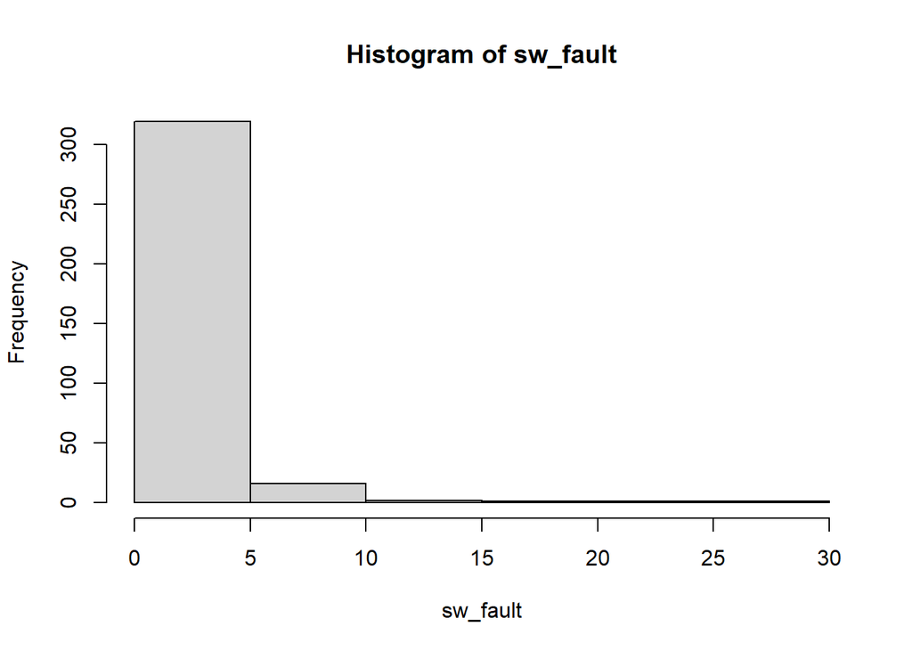

```r
hist(sw_fault)
```

It is also possible to show the histogram with different breaks.

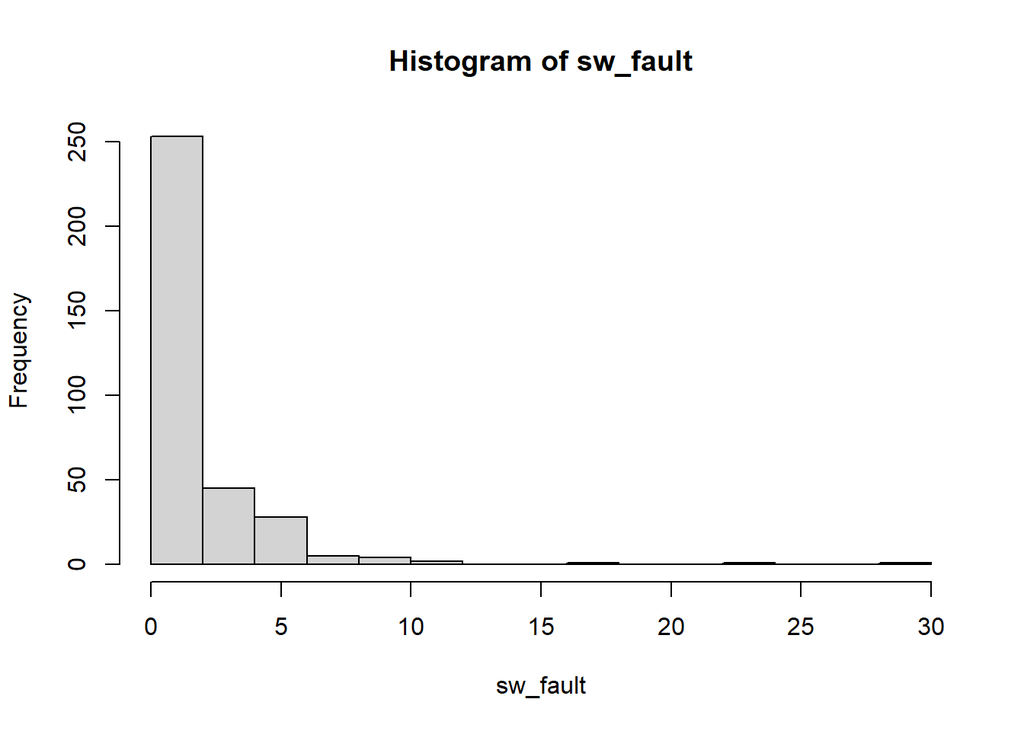

```r
hist(sw_fault, breaks=15)
```

In order to have a better idea of how the data are distributed, it is also possible to show a boxplot.

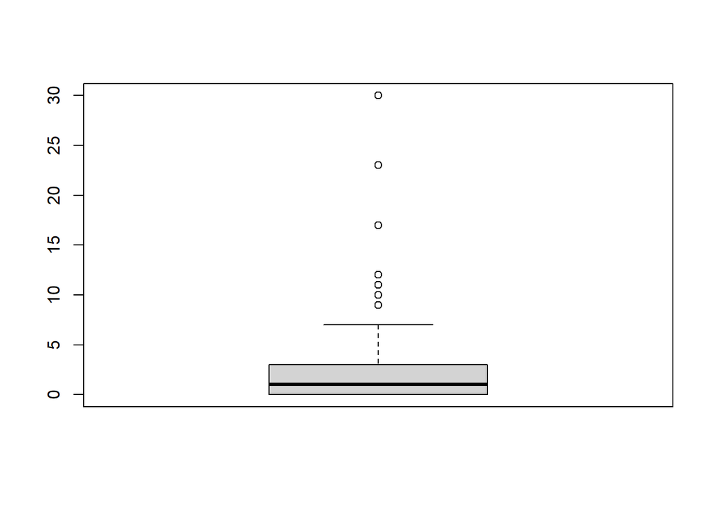

```r
boxplot(sw_fault)
```

# Selection and visualization of the independent variables

The independent variables must be taken among the columns available in the dataset. In particular, it has been chosen to take into consideration the following variables:

- Lines Of Code (LOC)
- Average Method Complexity (AMC)
- Measure Of Aggregation (MOA)
- Lack of COhesion in Methods (LCOM)

The first two variables take into account the dimension or the complexity of the artifacts. The last two variables take into account the class fields of the artifacts. A more detailed description is performed below.

## Selection and visualization of the independent variables - LOC

The variable LOC represents the number of lines of code based on the Java binary code. In particular, it is the sum of number of fields, number of methods and number of instructions in every method of the investigated class.

```r
loc <- lucene$loc

head(loc)
```

```
## [1]  84 286 287  26 596   8
```

The histogram and the boxplot of this variable are shown below.

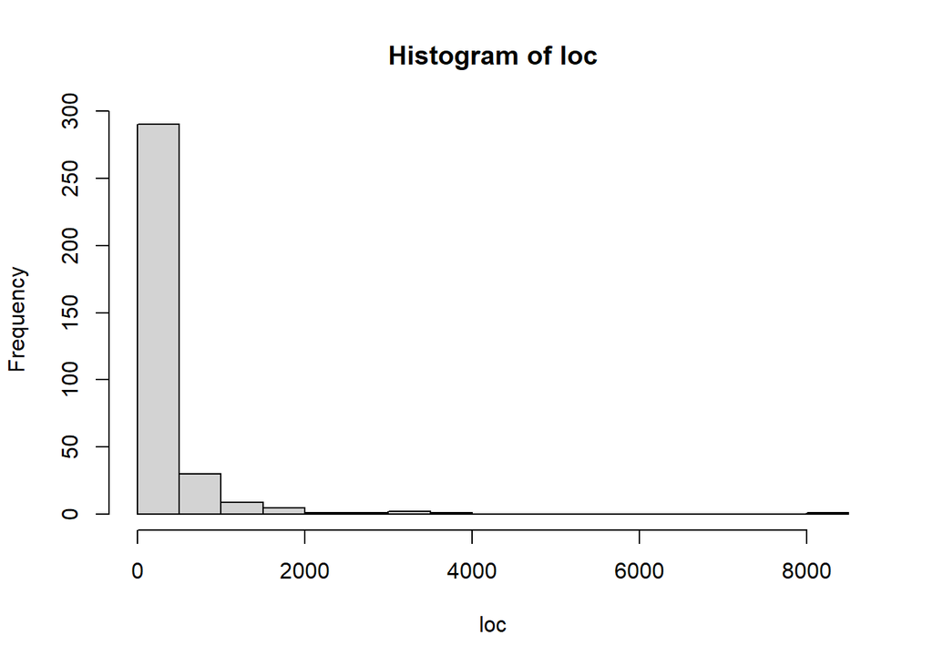

```r
hist(loc, breaks=15)
```

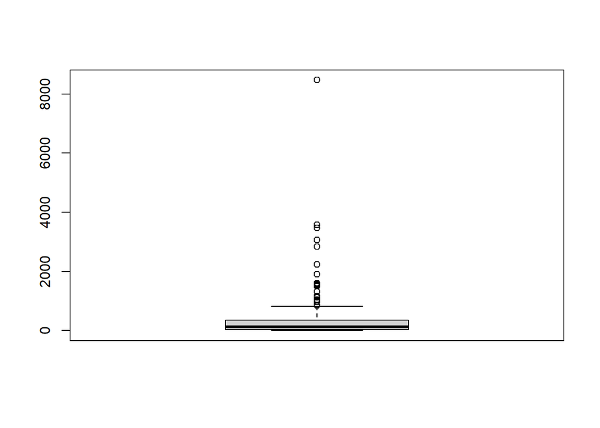

```r
boxplot(loc)
```

Since LOC is an independent variable, it is also possible to plot some diagrams that show the distribution of the dependent variable with respect to the values of the independent variable. In particular, a scatterplot and a boxplot are shown below.

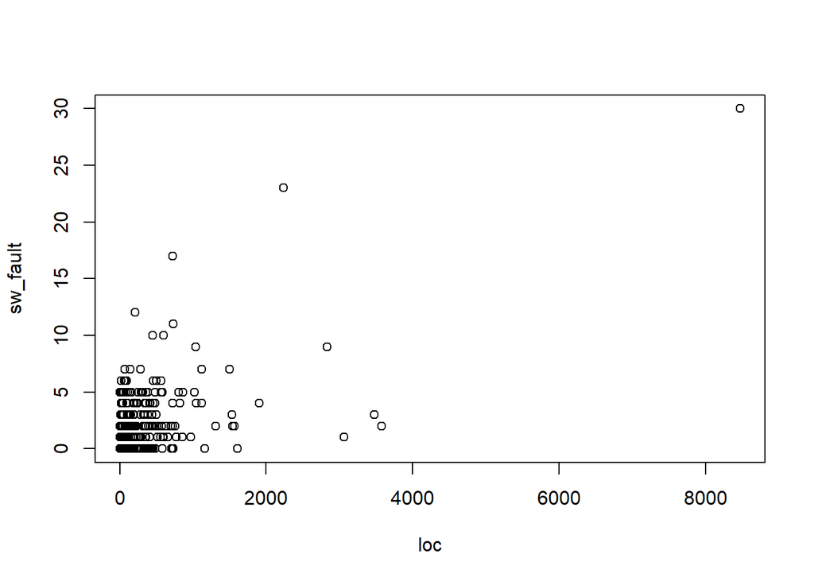

```r
plot(loc, sw_fault)
```

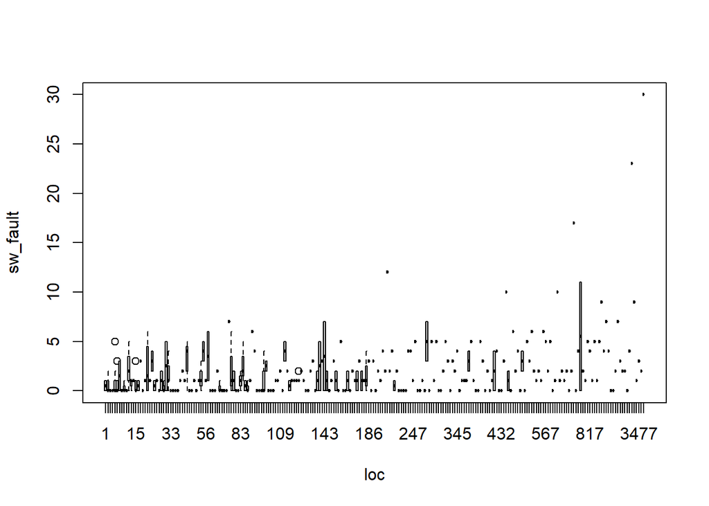

```r
boxplot(sw_fault~loc)
```

## Selection and visualization of the independent variables - AMC

The variable AMC measures the average method size for each class. Size of a method is equal to the number of Java binary codes in the method.

```r
amc <- lucene$amc

head(amc)
```

```
## [1] 14.40 27.20 27.50  5.50 22.36  0.60
```

The histogram and the boxplot of this variable are shown below.

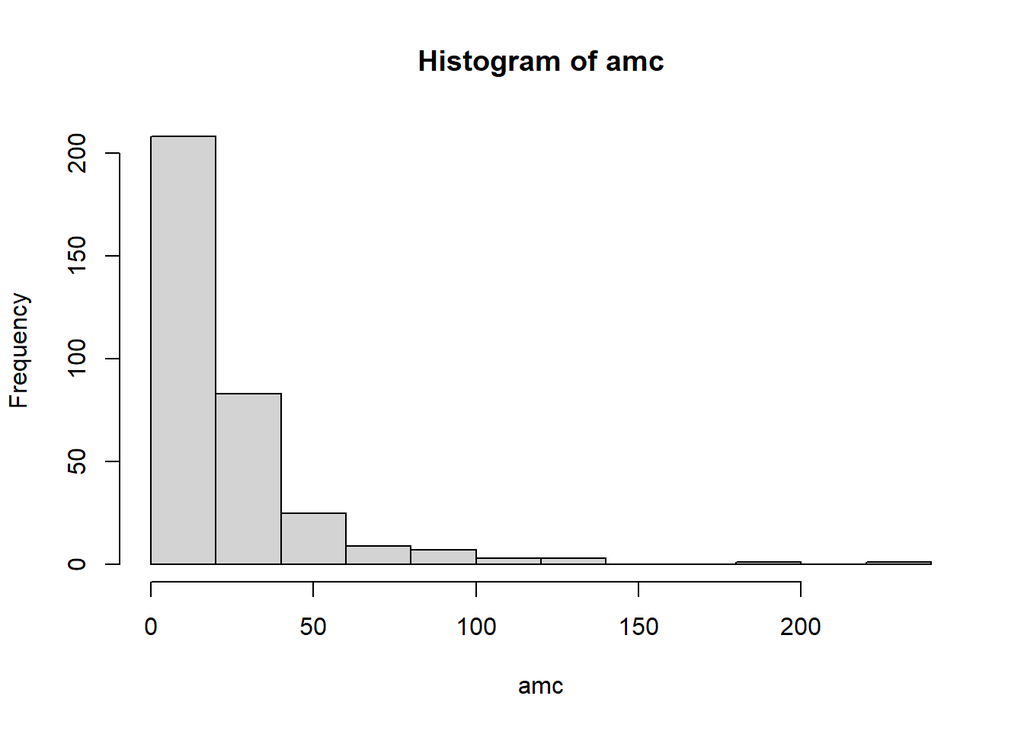

```r
hist(amc, breaks=10)
```

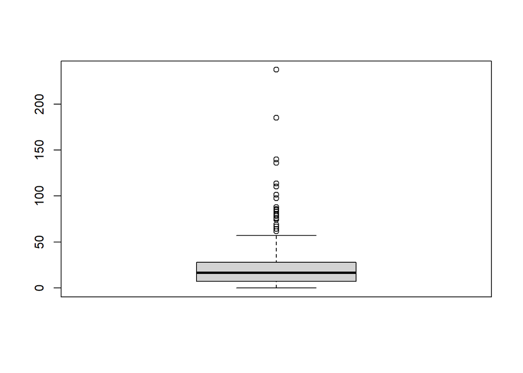

```r
boxplot(amc)
```

Since AMC is an independent variable, it is also possible to plot some diagrams that show the distribution of the dependent variable with respect to the values of the independent variable. In particular, a scatterplot and a boxplot are shown below.

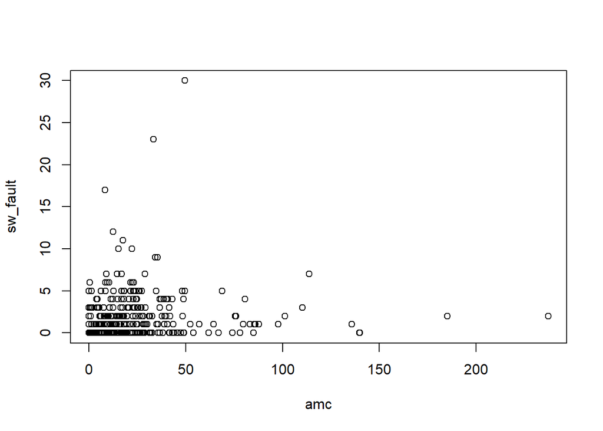

```r
plot(amc, sw_fault)
```

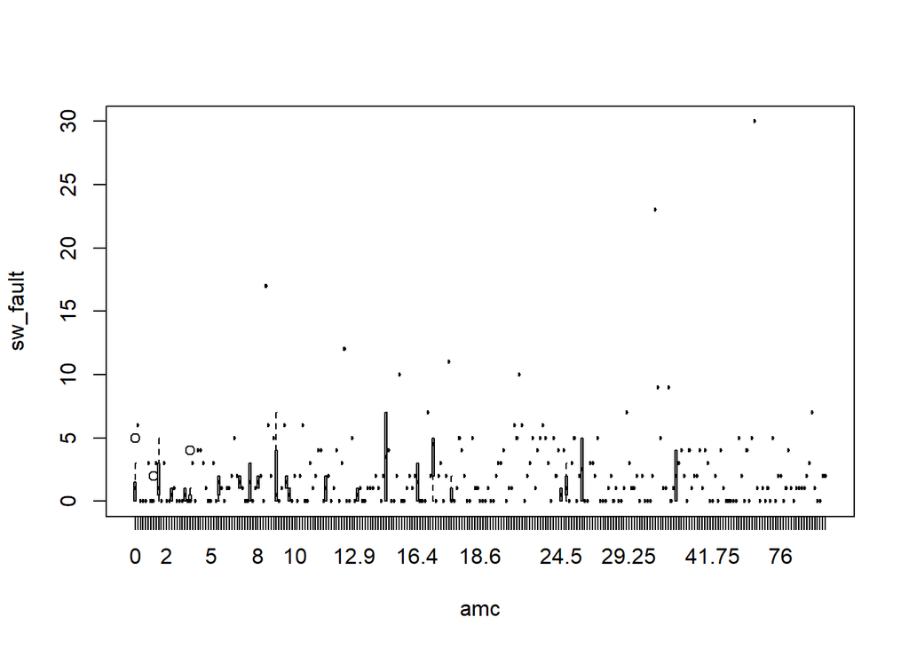

```r
boxplot(sw_fault~amc)
```

## Selection and visualization of the independent variables - MOA

The variable MOA measures the extent of the part-whole relationship, realized by using attributes. The metric is a count of the number of class fields whose types are user defined classes.

```r
moa <- lucene$moa

head(moa)
```

```
## [1] 7 0 0 0 5 0
```

The histogram and the boxplot of this variable are shown below.

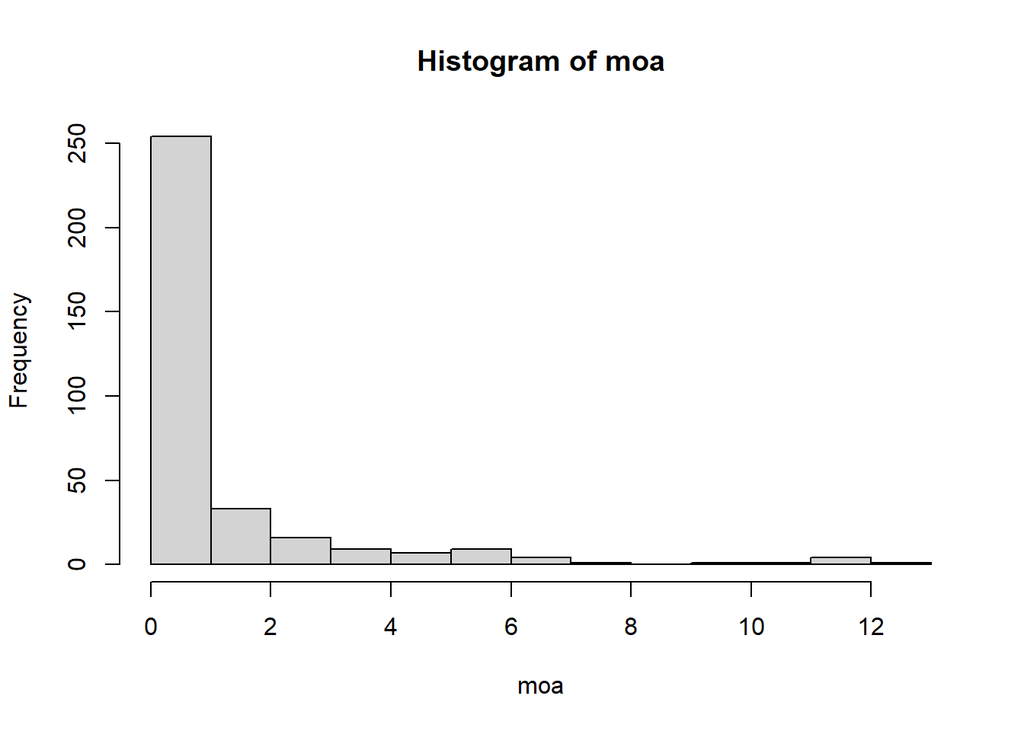

```r
hist(moa)
```

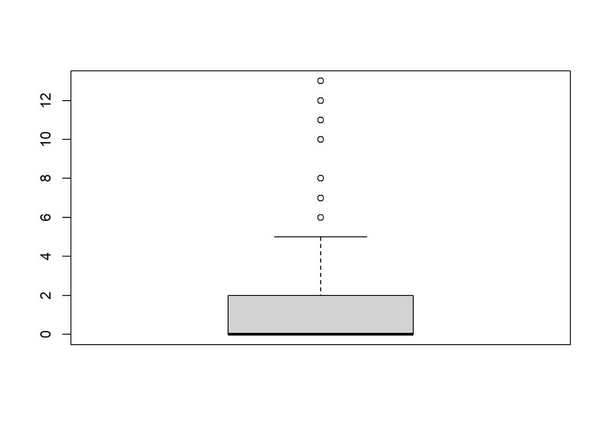

```r
boxplot(moa)
```

Since MOA is an independent variable, it is also possible to plot some diagrams that show the distribution of the dependent variable with respect to the values of the independent variable. In particular, a scatterplot and a boxplot are shown below.

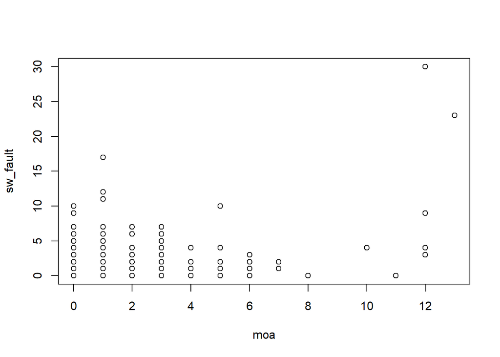

```r
plot(moa, sw_fault)
```

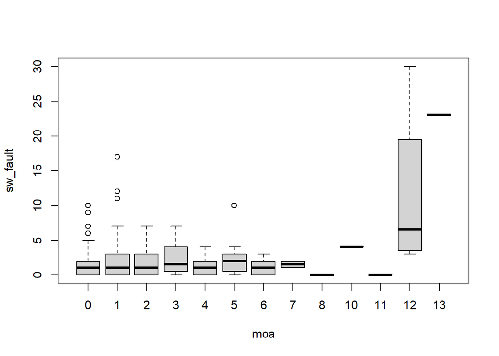

```r
boxplot(sw_fault~moa)
```

## Selection and visualization of the independent variables - LCOM

The variable LCOM counts the sets of methods in a class that are not related through the sharing of some of the class fields. In particular, it is calculated by subtracting from the number of method pairs that do not share a field access the number of method pairs that do.

```r
lcom <- lucene$lcom

head(lcom)
```

```
## [1]   0   7   0   6 160  10
```

The histogram and the boxplot of this variable are shown below.

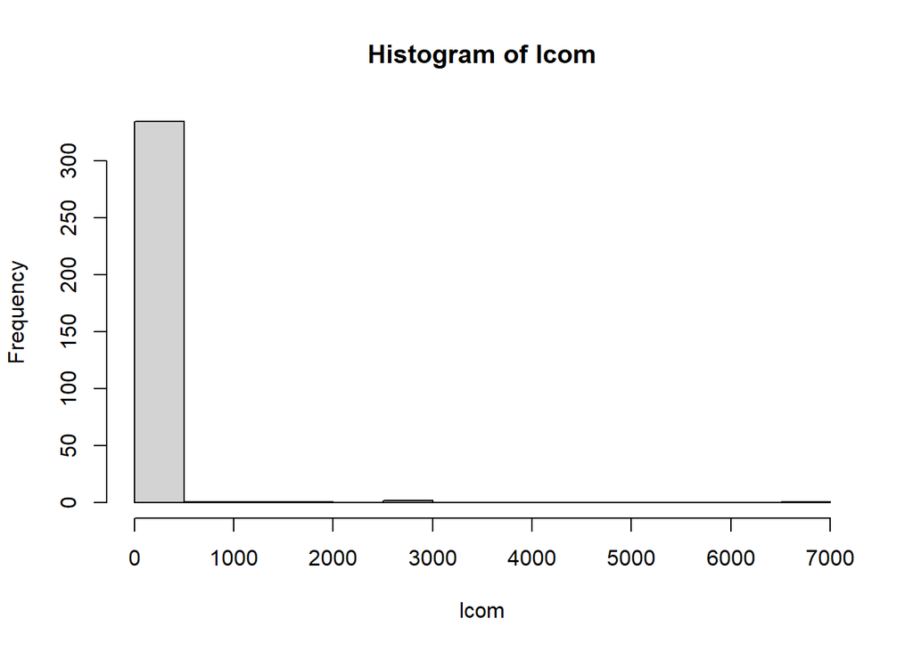

```r
hist(lcom, breaks=10)
```

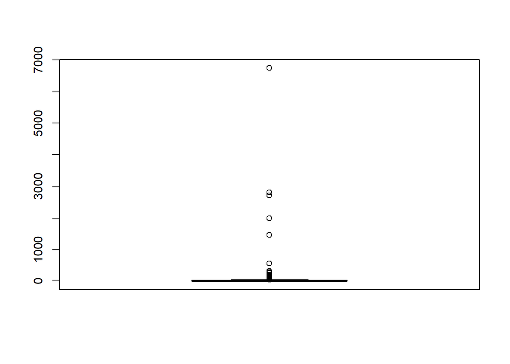

```r
boxplot(lcom)
```

Since LCOM is an independent variable, it is also possible to plot some diagrams that show the distribution of the dependent variable with respect to the values of the independent variable. In particular, a scatterplot and a boxplot are shown below.

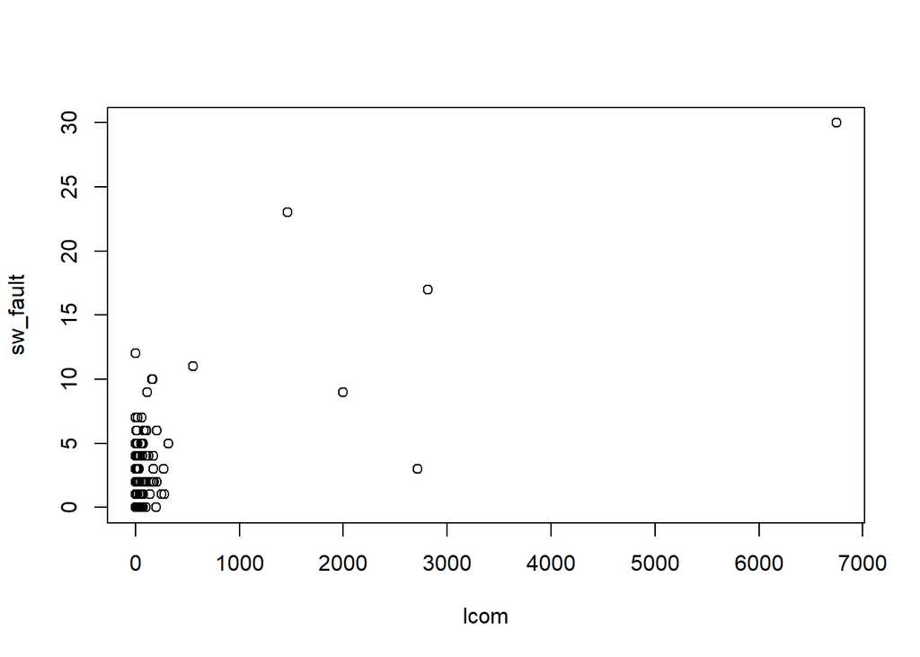

```r
plot(lcom, sw_fault)
```

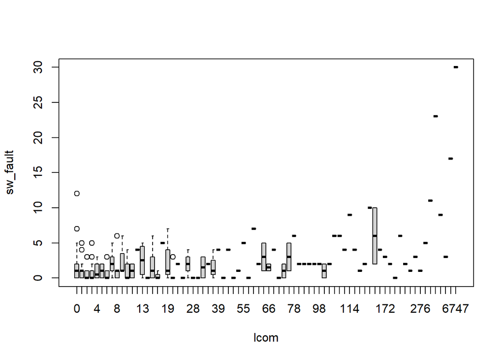

```r
boxplot(sw_fault~lcom)
```

# Descriptive Statistics

Descriptive statistics are used to quantitatively describe or summarize features from a collection of information.

In order to get a significant set of descriptive statistics, it should contain indicators that are able to provide information about the cardinality of the dataset, the central tendency indicator and the dispersion indicators. Since none of the considered variables is neither a nominal nor an ordinal scale, the set of descriptive statistics computed on the considered variables contains:

- Number of samples
- Minimum and Maximum values
- Median
- Mean
- Standard Deviation

The first step concerns the definition of a function that computes the descriptive statistics on a specific variable and then groups them into a table.

```r
descrStatsNames <- c('Samples Nr','Min','Max','Median','Mean','Std. Dev')

descriptive.statistics <- function(var) {
  samplesNumber <- length(var)
  min <- min(var)
  max <- max(var)
  median <- median(var)
  mean <- mean(var)
  stdDev <- sd(var)
  matrix <- matrix(c(samplesNumber, min, max, median, mean, stdDev), byrow=TRUE)
  rownames(matrix) <- descrStatsNames
  return (as.table(matrix))
}
```

This function will be used to compute the descriptive statistics for all the considered variables.

## Descriptive Statistics - Software Faultiness

```r
sw_fault_DescrStats <- descriptive.statistics(sw_fault)
colnames(sw_fault_DescrStats) <- c('Sw_Fault')
sw_fault_DescrStats
```

```
##              Sw_Fault
## Samples Nr 340.000000
## Min          0.000000
## Max         30.000000
## Median       1.000000
## Mean         1.858824
## Std. Dev     2.975427
```

## Descriptive Statistics - LOC

```r
loc_DescrStats <- descriptive.statistics(loc)
colnames(loc_DescrStats) <- c('LOC')
loc_DescrStats
```

```
##                  LOC
## Samples Nr  340.0000
## Min           1.0000
## Max        8474.0000
## Median      121.5000
## Mean        302.5265
## Std. Dev    639.3336
```

## Descriptive Statistics - AMC

```r
amc_DescrStats <- descriptive.statistics(amc)
colnames(amc_DescrStats) <- c('AMC')
amc_DescrStats
```

```
##                  AMC
## Samples Nr 340.00000
## Min          0.00000
## Max        237.20000
## Median      16.33889
## Mean        23.04441
## Std. Dev    27.15896
```

## Descriptive Statistics - MOA

```r
moa_DescrStats <- descriptive.statistics(moa)
colnames(moa_DescrStats) <- c('MOA')
moa_DescrStats
```

```
##                   MOA
## Samples Nr 340.000000
## Min          0.000000
## Max         13.000000
## Median       0.000000
## Mean         1.288235
## Std. Dev     2.214029
```

## Descriptive Statistics - LCOM

```r
lcom_DescrStats <- descriptive.statistics(lcom)
colnames(lcom_DescrStats) <- c('LCOM')
lcom_DescrStats
```

```
##                  LCOM
## Samples Nr  340.00000
## Min           0.00000
## Max        6747.00000
## Median        3.00000
## Mean         68.72353
## Std. Dev    442.98452
```

## Descriptive Statistics - Results

The descriptive statistics computed on all the considered variables can be reported into a single table.

```r
cbind(sw_fault_DescrStats, loc_DescrStats, amc_DescrStats, moa_DescrStats, lcom_DescrStats)
```

```
##              Sw_Fault       LOC       AMC        MOA       LCOM
## Samples Nr 340.000000  340.0000 340.00000 340.000000  340.00000
## Min          0.000000    1.0000   0.00000   0.000000    0.00000
## Max         30.000000 8474.0000 237.20000  13.000000 6747.00000
## Median       1.000000  121.5000  16.33889   0.000000    3.00000
## Mean         1.858824  302.5265  23.04441   1.288235   68.72353
## Std. Dev     2.975427  639.3336  27.15896   2.214029  442.98452
```

# Univariate statistically-significant model - OLS

The Ordinary Least Square (OLS) regression is a statistical technique used for the analysis and modelling of linear relationships between a dependent variable and one or more independent variables. If the relationship between two variables appears to be linear, then a straight line can be fit to the data in order to model the relationship.

## Univariate statistically-significant model - OLS - Software Faultiness vs LOC

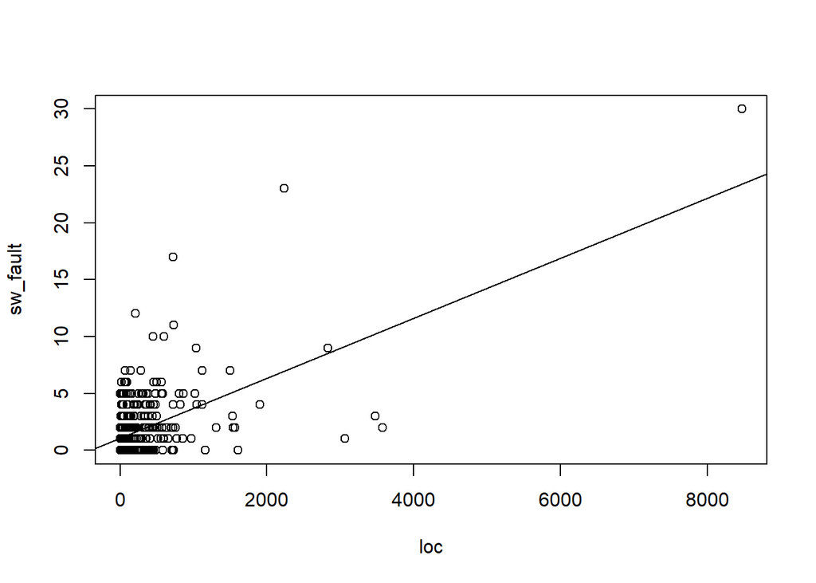

```r
sw_faultVSloc <- lm(sw_fault~loc)

plot(loc, sw_fault)
abline(sw_faultVSloc)
```

Before the application of the OLS technique, it is needed to verify whether its assumptions are met. In particular, the assumptions impose that the distribution of the two variables must be linear. This step is particularly important because it can be used to assess whether the obtained model can be considered statistically-significant.

In order to check whether the assumptions of the OLS technique are met, a correlation test can be used. In particular, a correlation test is a technique that is used to evaluate the association between two or more variables. The result of the application of a correlation test is a coefficient, that is a numeric value that measure the degree of association between the variables. There are several, well-known correlation coefficients that can be used to evaluate the association between variables:

- Pearson’s R: it is used to measure the degree of correlation between two variables. It is computed as the covariance of the two variables, divided by the product of their standard deviations. Its values are always between -1 and +1, where -1 implies a perfect negative correlation, 0 implies the absence of correlation and +1 implies a perfect positive correlation.
- Spearman’s rho: it is Pearson’s R applied to the ranked values rather than to the raw data. Even in this case, its values range between -1 and +1.
- Kendall’s tau: it is used to measure the degree of correlation between two variables. Even in this case, its values range between -1 and +1. However, Kendall’s tau is more robust and efficient than Spearman’s rho, and it is usually preferred when there are small samples and some outliers. Kendall’s tau is generally smaller than Spearman’s rho.

In order to check whether two variables are linearly dependent, it is also possible to use the Shapiro-Wilk’s test of normality. The null hypothesis of the test is that the data are normally distributed, while the alternative hypothesis is that the data are not normally distributed. The results of the Shapiro-Wilk test are the W coefficient and the p-value. In particular, if the p-value is less than 0.05, then the null hypothesis is rejected and there is the evidence that the data are not normally distributed. However, if the p-value is greater than 0.05, then the null hypothesis cannot be rejected and there is the evidence that the data are normally distributed.

### Check of the assumptions

The first step concerns the definition of a function that computes the main correlation coefficients over two variables.

```r
corrCoeffNames <- c('Pearson\'s R',
                    'Spearman\'s Rho',
                    'Kendall\'s Tau',
                    'Shapiro-Wilk p-value')

correlation.coefficients <- function(x,y,ols_model) {
  orig_pearson <- cor.test(x, y,
                          alternative="greater",
                          method="pearson")
  orig_r <- orig_pearson$estimate
  print(orig_pearson)

  orig_spearman <- cor.test(y, x,
                            alternative="two.sided",
                            method="spearman",
                            exact=FALSE)
  orig_rho <- orig_spearman$estimate
  print(orig_spearman)

  orig_kendall <- cor.test(y, x,
                           alternative="greater",
                           method="kendall")
  orig_tau <- orig_kendall$estimate
  print(orig_kendall)

  orig_shapiro <- shapiro.test(ols_model$residuals)
  orig_pvalue <- orig_shapiro$p.value
  print(orig_shapiro)

  matrix <- matrix(c(orig_r, orig_rho, orig_tau, orig_pvalue), byrow=TRUE)
  rownames(matrix) <- corrCoeffNames
  return (as.table(matrix))
}
```

```r
orig_corrCoeff <- correlation.coefficients(loc, sw_fault, sw_faultVSloc)
```

```
##
##  Pearson's product-moment correlation
##
## data:  x and y
## t = 12.653, df = 338, p-value < 2.2e-16
## alternative hypothesis: true correlation is greater than 0
## 95 percent confidence interval:
##  0.5030562 1.0000000
## sample estimates:
##       cor
## 0.5669322
##
##
##  Spearman's rank correlation rho
##
## data:  y and x
## S = 4238053, p-value = 2.047e-11
## alternative hypothesis: true rho is not equal to 0
## sample estimates:
##       rho
## 0.3530293
##
##
##  Kendall's rank correlation tau
##
## data:  y and x
## z = 6.6459, p-value = 1.506e-11
## alternative hypothesis: true tau is greater than 0
## sample estimates:
##       tau
## 0.2654379
##
##
##  Shapiro-Wilk normality test
##
## data:  ols_model$residuals
## W = 0.82309, p-value < 2.2e-16
```

```r
colnames(orig_corrCoeff) <- c('SwFaultVSLOC')
orig_corrCoeff
```

```
##                      SwFaultVSLOC
## Pearson's R          5.669322e-01
## Spearman's Rho       3.530293e-01
## Kendall's Tau        2.654379e-01
## Shapiro-Wilk p-value 5.090669e-19
```

According to the obtained results, the Pearson’s R coefficient shows a slight degree of correlation between the two variables. Even if their values are less significant, both the Spearman’s rho and the Kendall’s tau coefficients show a slight degree of correlation. However, the p-value computed by the Shapiro-Wilk test strongly rejects the normality of the data.

### Data transformation

Since it is not possible to establish whether the data are effectively linearly dependent, it can be useful to try to apply some data transformation techniques and then check again whether the assumptions of the OLS model are met by the new data. In particular, it is possible to adopt two different approaches.

### Data transformation - Logarithmic transformation

This technique implies that both the dependent and the independent variables are replaced by their logarithm. In particular, in order to avoid the creation of negative values, the data will be transformed according to the formula
$$var' = log(1 + var)$$

```r
log_sw_fault <- log(1+sw_fault)
log_loc <- log(1+loc)

log_sw_faultVSloc <- lm(log_sw_fault~log_loc)
```

```r
log_corrCoeff <- correlation.coefficients(log_loc, log_sw_fault, log_sw_faultVSloc)
```

```
##
##  Pearson's product-moment correlation
##
## data:  x and y
## t = 7.4936, df = 338, p-value = 2.959e-13
## alternative hypothesis: true correlation is greater than 0
## 95 percent confidence interval:
##  0.2981445 1.0000000
## sample estimates:
##     cor
## 0.37745
##
##
##  Spearman's rank correlation rho
##
## data:  y and x
## S = 4238053, p-value = 2.047e-11
## alternative hypothesis: true rho is not equal to 0
## sample estimates:
##       rho
## 0.3530293
##
##
##  Kendall's rank correlation tau
##
## data:  y and x
## z = 6.6459, p-value = 1.506e-11
## alternative hypothesis: true tau is greater than 0
## sample estimates:
##       tau
## 0.2654379
##
##
##  Shapiro-Wilk normality test
##
## data:  ols_model$residuals
## W = 0.97089, p-value = 2.421e-06
```

```r
colnames(log_corrCoeff) <- c('Log_SwFaultVSLOC')
log_corrCoeff
```

```
##                      Log_SwFaultVSLOC
## Pearson's R              3.774500e-01
## Spearman's Rho           3.530293e-01
## Kendall's Tau            2.654379e-01
## Shapiro-Wilk p-value     2.420526e-06
```

According to the obtained results and with the results obtained on the original data, the results of both the Spearman’s rho and the Kendall’s tau are not changed and the Pearson’s R is worse. Furthermore, the p-value computed by the Shapiro-Wilk test is still less than 0.05. So, this transformation did not work in this situation.

It is also possible to graphically check the differences between the two OLS lines of regression.

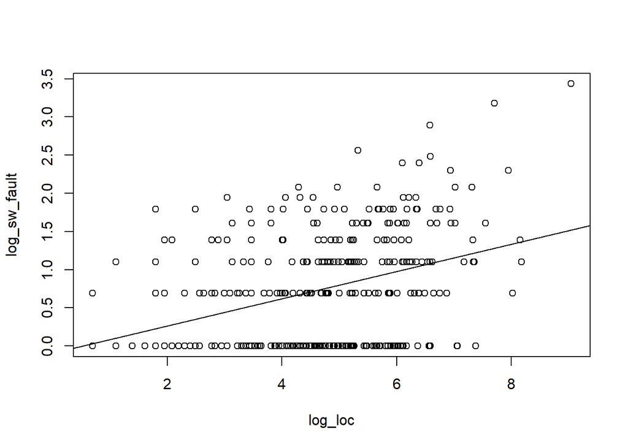

```r
plot(log_loc, log_sw_fault)
abline(log_sw_faultVSloc)
```

### Data transformation - Outliers Removal

Outliers are data-points with a heavy influence for the regression model. In particular, they can lead to the creation of incorrect or useless models. Outliers can be caused by corrupted data or rare statistical fluctuations. So, it can be particularly interesting to investigate the reasons that brought to their values.

In order to eliminate the outliers, it is important to adopt an iterative and automatic approach. In particular, one of the most important considerations that need to be taken into account is the evaluation of the model after the removal of each outlier.

The metric used to evaluate the influence of a data-point for the regression model is the Cook’s distance.

```r
cooksDistances <- cooks.distance(sw_faultVSloc)
head(cooksDistances)
```

```
##            1            2            3            4            5            6
## 2.186461e-05 3.448504e-04 8.117825e-04 3.722003e-04 1.615958e-02 3.488561e-04
```

A data-point is considered to be an outlier when its Cook’s distance is greater than a fixed threshold. In particular, it has been chosen to evaluate the results obtained by using two different threshold values. In the first case, the threshold is set to 4/L, where L is the number of samples. In the second case, the threshold is set to 1.

```r
sum(cooksDistances > 4/length(cooksDistances))
```

```
## [1] 14
```

```r
sum(cooksDistances > 1)
```

```
## [1] 1
```

Since it is preferable to remove the fewest number of data-points, the case in which the threshold equals 1 is analyzed as first.

### Data transformation - Outliers Removal - Threshold = 1

The first step of this procedure concerns the definition of a function that iteratively removes the outliers from the data.

```r
removeOutliersCook1 <- function(x,y) {
  done = FALSE
  while ( !done ) {
    model = lm(y ~ x)
    cooksDistances <- cooks.distance(model)
    maxCooksDistance = max(cooksDistances)
    l = length(y)
    if(maxCooksDistance < 1) { done = TRUE; break; }
    removeNext = which.max(cooksDistances)
    y = y[-c(removeNext)]
    x = x[-c(removeNext)]
  }
  return (list(x,y))
}
```

Then, the function is called on the variables LOC and Software Faultiness.

```r
nonOutliersCook1 <- removeOutliersCook1(loc, sw_fault)
```

In order to make the code more clear, two new variables are created.

```r
nonOutliersCook1_loc <- nonOutliersCook1[[1]]
nonOutliersCook1_sw_fault <- nonOutliersCook1[[2]]
```

Before the correlation coefficient are computed on the new data, it is important to check how many data-points has been removed.

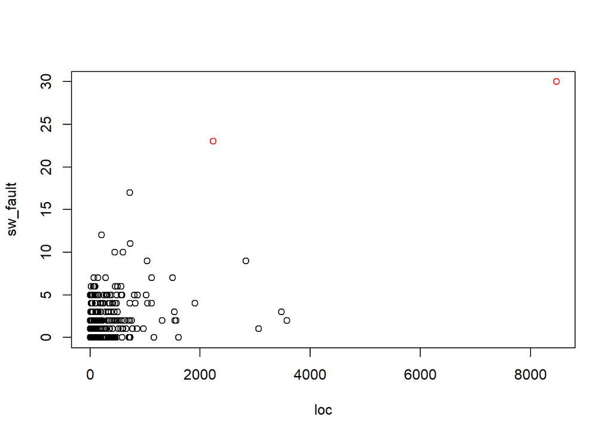

```r
plot(loc, sw_fault, col="red")
points(nonOutliersCook1_loc, nonOutliersCook1_sw_fault, col="black")
```

The model is finally re-created and the OLS assumptions are checked on the data with the outliers removed.

```r
nonOutliersCook1_sw_faultsVSloc <- lm(nonOutliersCook1_sw_fault~nonOutliersCook1_loc)

nonOutliersCook1_corrCoeff <- correlation.coefficients(nonOutliersCook1_loc,
                                                       nonOutliersCook1_sw_fault,
                                                       nonOutliersCook1_sw_faultsVSloc)
```

```
##
##  Pearson's product-moment correlation
##
## data:  x and y
## t = 5.1536, df = 336, p-value = 2.184e-07
## alternative hypothesis: true correlation is greater than 0
## 95 percent confidence interval:
##  0.1855323 1.0000000
## sample estimates:
##       cor
## 0.2706584
##
##
##  Spearman's rank correlation rho
##
## data:  y and x
## S = 4240386, p-value = 1.177e-10
## alternative hypothesis: true rho is not equal to 0
## sample estimates:
##       rho
## 0.3411138
##
##
##  Kendall's rank correlation tau
##
## data:  y and x
## z = 6.3741, p-value = 9.201e-11
## alternative hypothesis: true tau is greater than 0
## sample estimates:
##       tau
## 0.2556181
##
##
##  Shapiro-Wilk normality test
##
## data:  ols_model$residuals
## W = 0.81022, p-value < 2.2e-16
```

```r
colnames(nonOutliersCook1_corrCoeff) <- c('NonOutCook1_SwFaultVSLOC')
nonOutliersCook1_corrCoeff
```

```
##                      NonOutCook1_SwFaultVSLOC
## Pearson's R                      2.706584e-01
## Spearman's Rho                   3.411138e-01
## Kendall's Tau                    2.556181e-01
## Shapiro-Wilk p-value             1.305957e-19
```

Comparing the obtained results with the ones obtained on the original data, all the coefficients show worse results. In particular, the p-value computed by the Shapiro-Wilk test is less than 0.05. So, this transformation did not work in this situation.

It is also possible to graphically check the differences between the two OLS lines of regression.

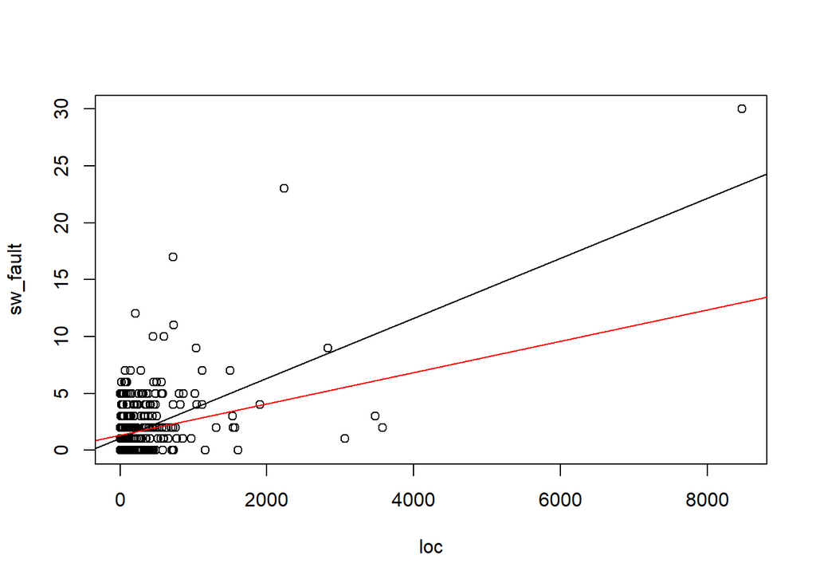

```r
plot(loc, sw_fault)
abline(sw_faultVSloc)
abline(nonOutliersCook1_sw_faultsVSloc, col="red")
```

### Data transformation - Outliers Removal - Threshold = 4/L

Even in this case, the first step of this procedure concerns the definition of a function that iteratively removes the outliers from the data.

```r
removeOutliersCook4l <- function(x,y) {
  done = FALSE
  while ( !done ) {
    model = lm(y ~ x)
    cooksDistances <- cooks.distance(model)
    maxCooksDistance = max(cooksDistances)
    l = length(y)
    if(maxCooksDistance < 4/l) { done = TRUE; break; }
    removeNext = which.max(cooksDistances)
    y = y[-c(removeNext)]
    x = x[-c(removeNext)]
  }
  return (list(x,y))
}
```

Then, the function is called on the variables LOC and Software Faultiness.

```r
nonOutliersCook4l <- removeOutliersCook4l(loc, sw_fault)
```

In order to make the code more clear, two new variables are created.

```r
nonOutliersCook4l_loc <- nonOutliersCook4l[[1]]
nonOutliersCook4l_sw_fault <- nonOutliersCook4l[[2]]
```

Before the correlation coefficient are computed on the new data, it is important to check how many data-points has been removed.

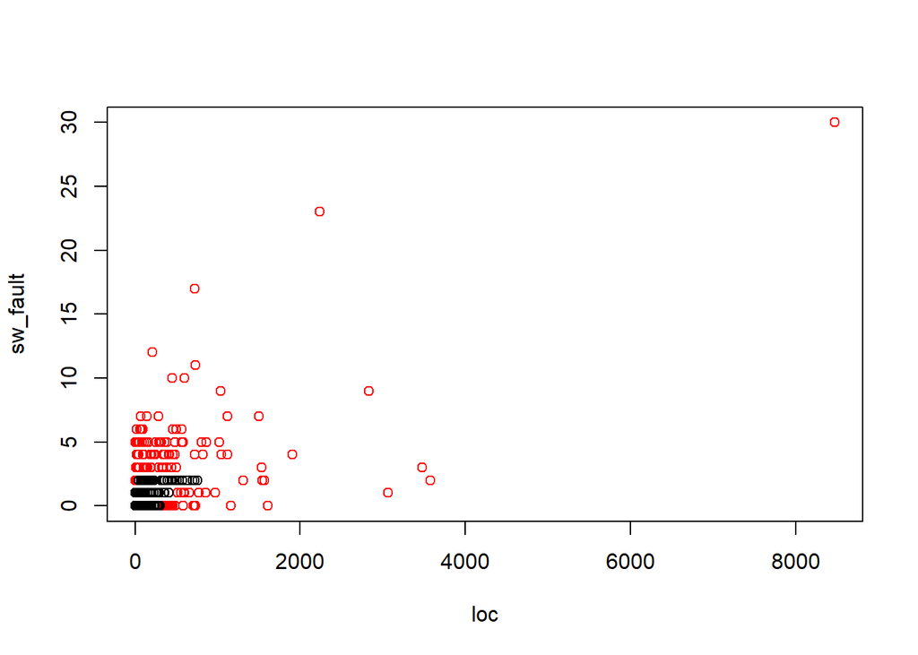

```r
plot(loc, sw_fault, col="red")
points(nonOutliersCook4l_loc, nonOutliersCook4l_sw_fault, col="black")
```

In particular, in this case the scatterplot shows that a very huge number of data-points has been considered outliers and has been removed from the original data. This is a possible reason to support the choice to consider this model as not statistically-significant.

```r
cat("Data-points in the original data:",
    length(sw_fault))
```

```
## Data-points in the original data: 340
```

```r
cat("Data-points removed from the original data:",
    length(sw_fault) - length(nonOutliersCook4l_sw_fault))
```

```
## Data-points removed from the original data: 127
```

The model is finally re-created and the OLS assumptions are checked on the data with the outliers removed.

```r
nonOutliersCook4l_sw_faultsVSloc <- lm(nonOutliersCook4l_sw_fault~nonOutliersCook4l_loc)

nonOutliersCook4l_corrCoeff <- correlation.coefficients(nonOutliersCook4l_loc,
                                                        nonOutliersCook4l_sw_fault,
                                                        nonOutliersCook4l_sw_faultsVSloc)
```

```
##
##  Pearson's product-moment correlation
##
## data:  x and y
## t = 7.9569, df = 211, p-value = 5.333e-14
## alternative hypothesis: true correlation is greater than 0
## 95 percent confidence interval:
##  0.3884948 1.0000000
## sample estimates:
##       cor
## 0.4804212
##
##
##  Spearman's rank correlation rho
##
## data:  y and x
## S = 965373, p-value = 1.293e-09
## alternative hypothesis: true rho is not equal to 0
## sample estimates:
##       rho
## 0.4005996
##
##
##  Kendall's rank correlation tau
##
## data:  y and x
## z = 5.936, p-value = 1.46e-09
## alternative hypothesis: true tau is greater than 0
## sample estimates:
##       tau
## 0.3194112
##
##
##  Shapiro-Wilk normality test
##
## data:  ols_model$residuals
## W = 0.91724, p-value = 1.533e-09
```

```r
colnames(nonOutliersCook4l_corrCoeff) <- c('NonOutCook4l_SwFaultVSLOC')
nonOutliersCook4l_corrCoeff
```

```
##                      NonOutCook4l_SwFaultVSLOC
## Pearson's R                       4.804212e-01
## Spearman's Rho                    4.005996e-01
## Kendall's Tau                     3.194112e-01
## Shapiro-Wilk p-value              1.533034e-09
```

Comparing the obtained results with the ones obtained on the original data, the Pearson’s R coefficient is slightly decreased, but both the Spearman’s rho and the Kendall’s tau are slightly increased. However, the p-value computed by the Shapiro-Wilk test is still less than 0.05. So, this transformation did not work in this situation.

It is also possible to graphically check the differences between the two OLS lines of regression.

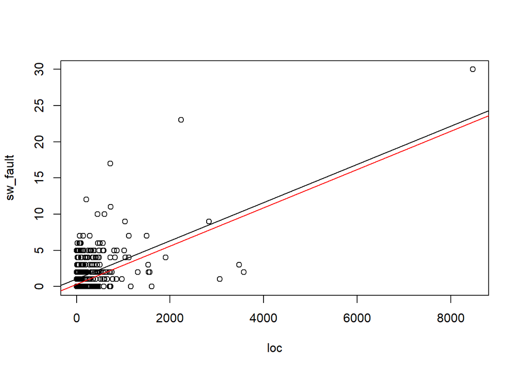

```r
plot(loc, sw_fault)
abline(sw_faultVSloc)
abline(nonOutliersCook4l_sw_faultsVSloc, col="red")
```

### Final considerations

The application of the OLS technique on the variables LOC and Software Faultiness is not possible, because these two variables are not linearly dependent.

In particular, it is possible to report the main coefficient that evaluate the linear dependency of these two variables over the different analysis performed.

```r
cbind(orig_corrCoeff, log_corrCoeff, nonOutliersCook1_corrCoeff, nonOutliersCook4l_corrCoeff)
```

```
##                      SwFaultVSLOC Log_SwFaultVSLOC NonOutCook1_SwFaultVSLOC
## Pearson's R          5.669322e-01     3.774500e-01             2.706584e-01
## Spearman's Rho       3.530293e-01     3.530293e-01             3.411138e-01
## Kendall's Tau        2.654379e-01     2.654379e-01             2.556181e-01
## Shapiro-Wilk p-value 5.090669e-19     2.420526e-06             1.305957e-19
##                      NonOutCook4l_SwFaultVSLOC
## Pearson's R                       4.804212e-01
## Spearman's Rho                    4.005996e-01
## Kendall's Tau                     3.194112e-01
## Shapiro-Wilk p-value              1.533034e-09
```

Looking at the above table, it is possible to state that only the original data show a slight degree of correlation. In particular, all the data transformation techniques reduce the degree of linear dependency among the two variables.

## Univariate statistically-significant model - OLS - Software Faultiness vs AMC

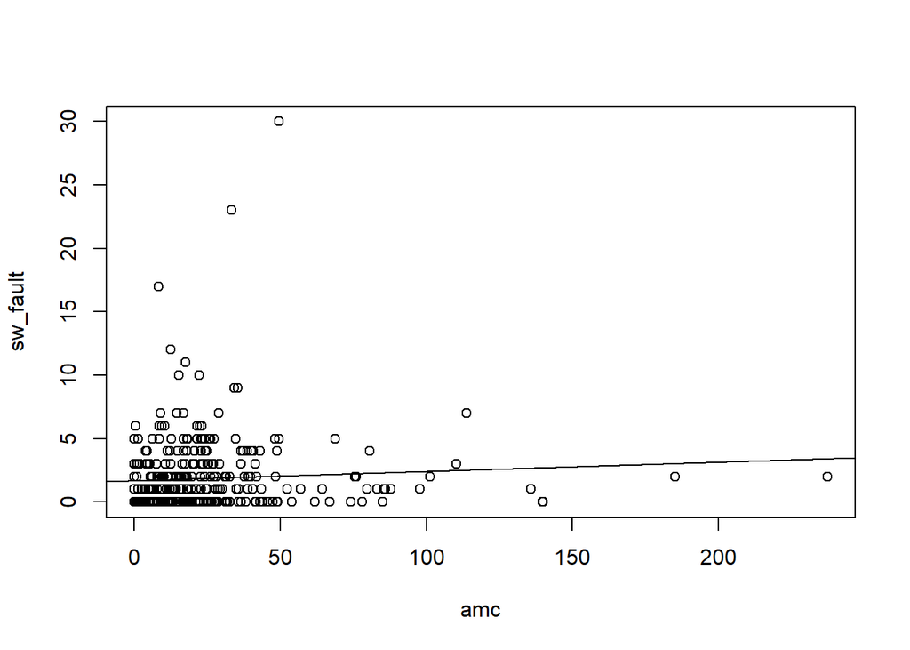

```r
sw_faultVSamc <- lm(sw_fault~amc)

plot(amc, sw_fault)
abline(sw_faultVSamc)
```

The steps performed to evaluate the results of the OLS technique applied to the variables Software Faultiness and AMC are the same performed in the previous analysis.

### Check of the assumptions

```r
orig_corrCoeff <- correlation.coefficients(amc, sw_fault, sw_faultVSamc)
```

```
##
##  Pearson's product-moment correlation
##
## data:  x and y
## t = 1.2337, df = 338, p-value = 0.1091
## alternative hypothesis: true correlation is greater than 0
## 95 percent confidence interval:
##  -0.02254027  1.00000000
## sample estimates:
##        cor
## 0.06695646
##
##
##  Spearman's rank correlation rho
##
## data:  y and x
## S = 5435390, p-value = 0.001629
## alternative hypothesis: true rho is not equal to 0
## sample estimates:
##       rho
## 0.1702467
##
##
##  Kendall's rank correlation tau
##
## data:  y and x
## z = 3.1334, p-value = 0.0008641
## alternative hypothesis: true tau is greater than 0
## sample estimates:
##       tau
## 0.1251595
##
##
##  Shapiro-Wilk normality test
##
## data:  ols_model$residuals
## W = 0.61835, p-value < 2.2e-16
```

```r
colnames(orig_corrCoeff) <- c('SwFaultVSAMC')
orig_corrCoeff
```

```
##                      SwFaultVSAMC
## Pearson's R          6.695646e-02
## Spearman's Rho       1.702467e-01
## Kendall's Tau        1.251595e-01
## Shapiro-Wilk p-value 8.840700e-27
```

According to the obtained results, all the coefficients show bad results. In particular, the p-value computed by the Shapiro-Wilk test is less than 0.05.

### Data transformation - Logarithmic transformation

```r
log_sw_fault <- log(1+sw_fault)
log_amc <- log(1+amc)

log_sw_faultVSamc <- lm(log_sw_fault~log_amc)
```

```r
log_corrCoeff <- correlation.coefficients(log_amc, log_sw_fault, log_sw_faultVSamc)
```

```
##
##  Pearson's product-moment correlation
##
## data:  x and y
## t = 3.4151, df = 338, p-value = 0.0003576
## alternative hypothesis: true correlation is greater than 0
## 95 percent confidence interval:
##  0.0948165 1.0000000
## sample estimates:
##       cor
## 0.1826309
##
##
##  Spearman's rank correlation rho
##
## data:  y and x
## S = 5435390, p-value = 0.001629
## alternative hypothesis: true rho is not equal to 0
## sample estimates:
##       rho
## 0.1702467
##
##
##  Kendall's rank correlation tau
##
## data:  y and x
## z = 3.1334, p-value = 0.0008641
## alternative hypothesis: true tau is greater than 0
## sample estimates:
##       tau
## 0.1251595
##
##
##  Shapiro-Wilk normality test
##
## data:  ols_model$residuals
## W = 0.93211, p-value = 2.491e-11
```

```r
colnames(log_corrCoeff) <- c('Log_SwFaultVSAMC')
log_corrCoeff
```

```
##                      Log_SwFaultVSAMC
## Pearson's R              1.826309e-01
## Spearman's Rho           1.702467e-01
## Kendall's Tau            1.251595e-01
## Shapiro-Wilk p-value     2.491235e-11
```

According to the obtained results and with the results obtained on the original data, the results of both the Spearman’s rho and the Kendall’s tau are not changed and the Pearson’s R is slightly increased. However, the p-value computed by the Shapiro-Wilk test is still less than 0.05. So, this transformation did not work in this situation.

It is also possible to graphically check that the data are not linearly dependent.

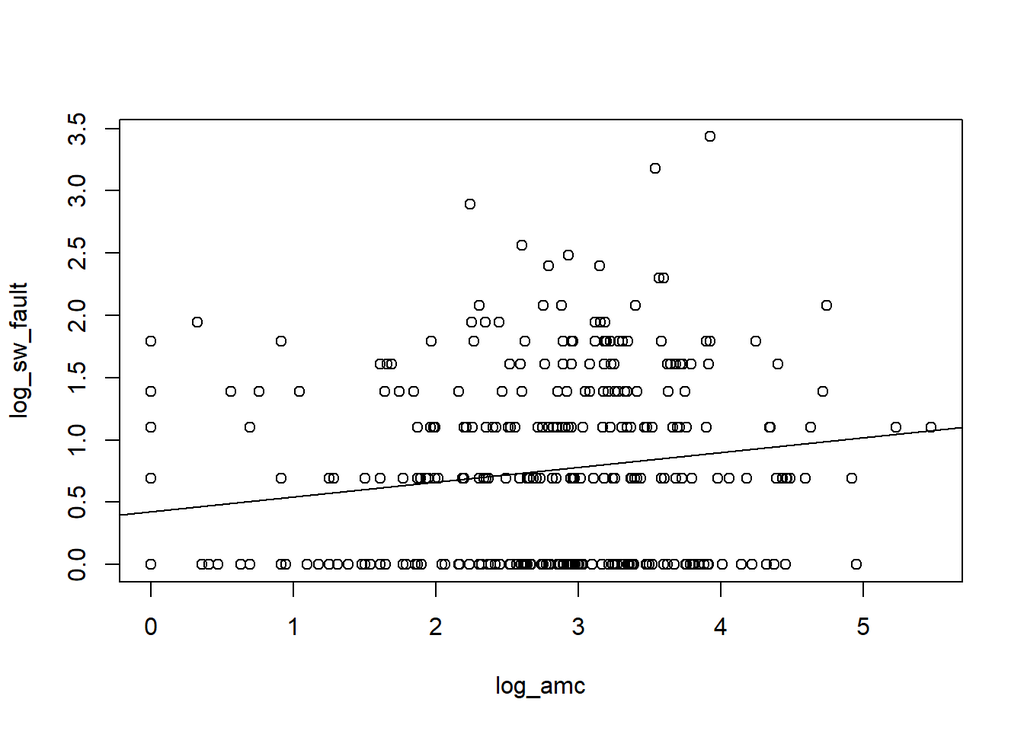

```r
plot(log_amc, log_sw_fault)
abline(log_sw_faultVSamc)
```

### Data transformation - Outliers Removal

```r
cooksDistances <- cooks.distance(sw_faultVSamc)
sum(cooksDistances > 4/length(cooksDistances))
```

```
## [1] 10
```

```r
sum(cooksDistances > 1)
```

```
## [1] 0
```

Since there are no data-points with a Cook’s distance greater than 1, this case is not analyzed.

### Data transformation - Outliers Removal - Threshold = 4/L

In order to remove the outliers according to a threshold value equal to 4/L, the same function defined before is used.

```r
nonOutliersCook4l <- removeOutliersCook4l(amc, sw_fault)
```

In order to make the code more clear, two new variables are created.

```r
nonOutliersCook4l_amc <- nonOutliersCook4l[[1]]
nonOutliersCook4l_sw_fault <- nonOutliersCook4l[[2]]
```

Before the correlation coefficient are computed on the new data, it is important to check how many data-points has been removed.

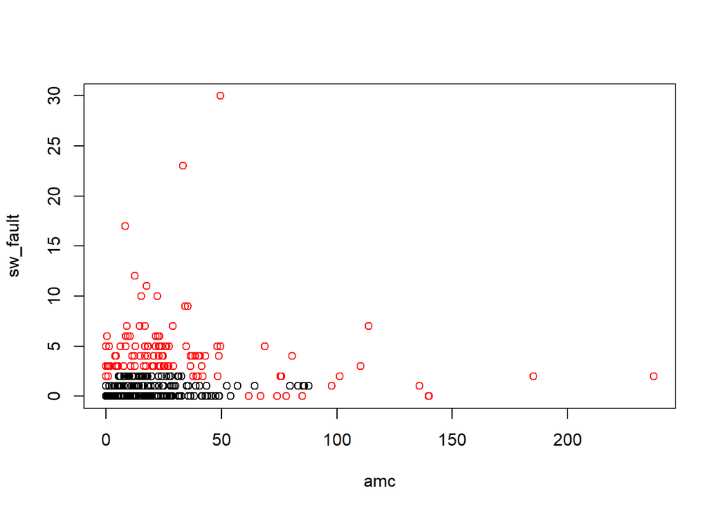

```r
plot(amc, sw_fault, col="red")
points(nonOutliersCook4l_amc, nonOutliersCook4l_sw_fault, col="black")
```

Even in this case, the scatterplot shows that a very huge number of data-points has been considered outliers and has been removed from the original data. This is a possible reason to support the choice to consider this model as not statistically-significant.

```r
cat("Data-points in the original data:",
    length(sw_fault))
```

```
## Data-points in the original data: 340
```

```r
cat("Data-points removed from the original data:",
    length(sw_fault) - length(nonOutliersCook4l_sw_fault))
```

```
## Data-points removed from the original data: 109
```

The model is finally re-created and the OLS assumptions are checked on the data with the outliers removed.

```r
nonOutliersCook4l_sw_faultsVSamc <- lm(nonOutliersCook4l_sw_fault~nonOutliersCook4l_amc)

nonOutliersCook4l_corrCoeff <- correlation.coefficients(nonOutliersCook4l_amc,
                                                        nonOutliersCook4l_sw_fault,
                                                        nonOutliersCook4l_sw_faultsVSamc)
```

```
##
##  Pearson's product-moment correlation
##
## data:  x and y
## t = 1.3972, df = 229, p-value = 0.08185
## alternative hypothesis: true correlation is greater than 0
## 95 percent confidence interval:
##  -0.01673179  1.00000000
## sample estimates:
##        cor
## 0.09193937
##
##
##  Spearman's rank correlation rho
##
## data:  y and x
## S = 1776961, p-value = 0.04031
## alternative hypothesis: true rho is not equal to 0
## sample estimates:
##       rho
## 0.1350295
##
##
##  Kendall's rank correlation tau
##
## data:  y and x
## z = 2.0406, p-value = 0.02065
## alternative hypothesis: true tau is greater than 0
## sample estimates:
##       tau
## 0.1057326
##
##
##  Shapiro-Wilk normality test
##
## data:  ols_model$residuals
## W = 0.78173, p-value < 2.2e-16
```

```r
colnames(nonOutliersCook4l_corrCoeff) <- c('NonOutCook4l_SwFaultVSAMC')
nonOutliersCook4l_corrCoeff
```

```
##                      NonOutCook4l_SwFaultVSAMC
## Pearson's R                       9.193937e-02
## Spearman's Rho                    1.350295e-01
## Kendall's Tau                     1.057326e-01
## Shapiro-Wilk p-value              3.028734e-17
```

Comparing the obtained results with the ones obtained on the original data, the Pearson’s R coefficient is slightly increased, but both the Spearman’s rho, but the Kendall’s tau are slightly decreased. However, the p-value computed by the Shapiro-Wilk test is still less than 0.05. So, this transformation did not work in this situation.

It is also possible to graphically check the differences between the two OLS lines of regression.

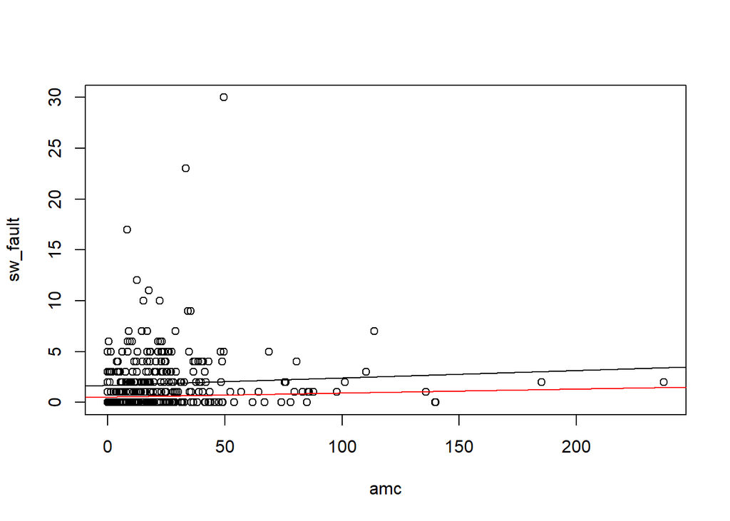

```r
plot(amc, sw_fault)
abline(sw_faultVSamc)
abline(nonOutliersCook4l_sw_faultsVSamc, col="red")
```

### Final considerations

The application of the OLS technique on the variables AMC and Software Faultiness is not possible, because these two variables are not linearly dependent.

In particular, it is possible to report the main coefficient that evaluate the linear dependency of these two variables over the different analysis performed.

```r
cbind(orig_corrCoeff, log_corrCoeff, nonOutliersCook4l_corrCoeff)
```

```
##                      SwFaultVSAMC Log_SwFaultVSAMC NonOutCook4l_SwFaultVSAMC
## Pearson's R          6.695646e-02     1.826309e-01              9.193937e-02
## Spearman's Rho       1.702467e-01     1.702467e-01              1.350295e-01
## Kendall's Tau        1.251595e-01     1.251595e-01              1.057326e-01
## Shapiro-Wilk p-value 8.840700e-27     2.491235e-11              3.028734e-17
```

Looking at the above table, it is possible to state that none of the data transformation techniques allow the data to be linearly dependent.

## Univariate statistically-significant model - OLS - Software Faultiness vs MOA

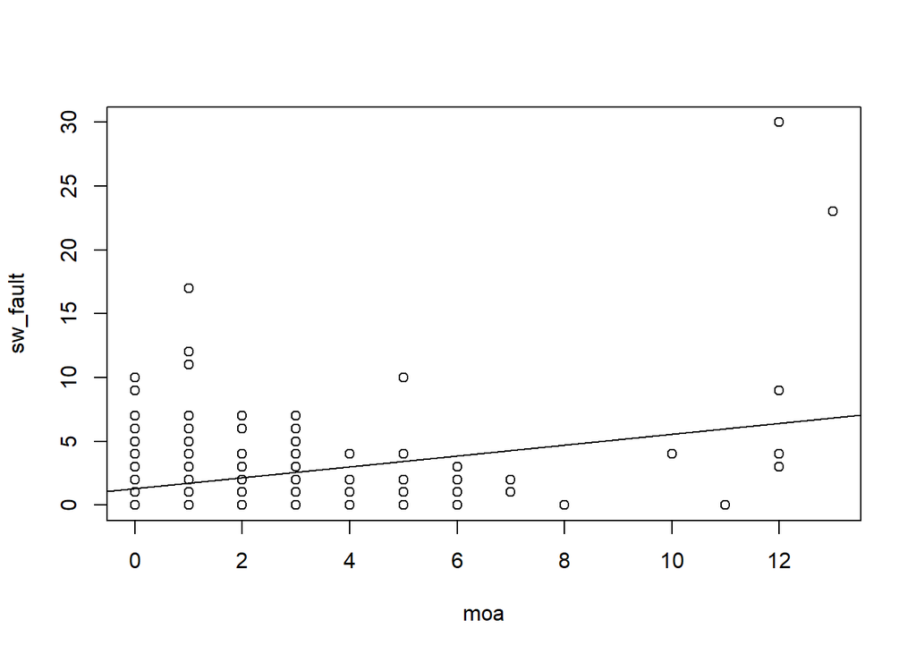

```r
sw_faultVSmoa <- lm(sw_fault~moa)

plot(moa, sw_fault)
abline(sw_faultVSmoa)
```

The steps performed to evaluate the results of the OLS technique applied to the variables Software Faultiness and MOA are the same performed in the previous analysis.

### Check of the assumptions

```r
orig_corrCoeff <- correlation.coefficients(moa, sw_fault, sw_faultVSmoa)
```

```
##
##  Pearson's product-moment correlation
##
## data:  x and y
## t = 6.144, df = 338, p-value = 1.132e-09
## alternative hypothesis: true correlation is greater than 0
## 95 percent confidence interval:
##  0.234229 1.000000
## sample estimates:
##       cor
## 0.3169566
##
##
##  Spearman's rank correlation rho
##
## data:  y and x
## S = 5689514, p-value = 0.01529
## alternative hypothesis: true rho is not equal to 0
## sample estimates:
##       rho
## 0.1314528
##
##
##  Kendall's rank correlation tau
##
## data:  y and x
## z = 2.418, p-value = 0.007803
## alternative hypothesis: true tau is greater than 0
## sample estimates:
##       tau
## 0.1085797
##
##
##  Shapiro-Wilk normality test
##
## data:  ols_model$residuals
## W = 0.74232, p-value < 2.2e-16
```

```r
colnames(orig_corrCoeff) <- c('SwFaultVSMOA')
orig_corrCoeff
```

```
##                      SwFaultVSMOA
## Pearson's R          3.169566e-01
## Spearman's Rho       1.314528e-01
## Kendall's Tau        1.085797e-01
## Shapiro-Wilk p-value 1.224719e-22
```

According to the obtained results, the Pearson’s R coefficient shows a very slight degree of correlation, but both the Spearman’s rho and the Kendall’s tau are quite near to 0. The p-value computed by the Shapiro-Wilk test is less than 0.05.

### Data transformation - Logarithmic transformation

```r
log_sw_fault <- log(1+sw_fault)
log_moa <- log(1+moa)

log_sw_faultVSmoa <- lm(log_sw_fault~log_moa)
```

```r
log_corrCoeff <- correlation.coefficients(log_moa, log_sw_fault, log_sw_faultVSmoa)
```

```
##
##  Pearson's product-moment correlation
##
## data:  x and y
## t = 3.1798, df = 338, p-value = 0.000805
## alternative hypothesis: true correlation is greater than 0
## 95 percent confidence interval:
##  0.08232034 1.00000000
## sample estimates:
##       cor
## 0.1704285
##
##
##  Spearman's rank correlation rho
##
## data:  y and x
## S = 5689514, p-value = 0.01529
## alternative hypothesis: true rho is not equal to 0
## sample estimates:
##       rho
## 0.1314528
##
##
##  Kendall's rank correlation tau
##
## data:  y and x
## z = 2.418, p-value = 0.007803
## alternative hypothesis: true tau is greater than 0
## sample estimates:
##       tau
## 0.1085797
##
##
##  Shapiro-Wilk normality test
##
## data:  ols_model$residuals
## W = 0.92385, p-value = 3.892e-12
```

```r
colnames(log_corrCoeff) <- c('Log_SwFaultVSMOA')
log_corrCoeff
```

```
##                      Log_SwFaultVSMOA
## Pearson's R              1.704285e-01
## Spearman's Rho           1.314528e-01
## Kendall's Tau            1.085797e-01
## Shapiro-Wilk p-value     3.891942e-12
```

According to the obtained results and with the results obtained on the original data, the results of both the Spearman’s rho and the Kendall’s tau are not changed, but the Pearson’s R is slightly decreased. Furthermore, the p-value computed by the Shapiro-Wilk test is still less than 0.05. So, this transformation did not work in this situation.

It is also possible to graphically check that the data are not linearly dependent.

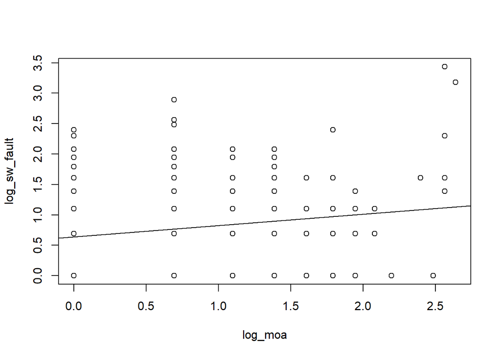

```r
plot(log_moa, log_sw_fault)
abline(log_sw_faultVSmoa)
```

### Data transformation - Outliers Removal

```r
cooksDistances <- cooks.distance(sw_faultVSmoa)
sum(cooksDistances > 4/length(cooksDistances))
```

```
## [1] 19
```

```r
sum(cooksDistances > 1)
```

```
## [1] 2
```

Since it is preferable to remove the fewest number of data-points, the case in which the threshold equals 1 is analyzed as first.